# Praktikum 6 Anreg

# Library

```r
library(readxl)    # untuk membaca data
library(GGally)    # untuk menghasilkan matriks hubungan antarpeubah
library(corrplot)  # untuk menghasilkan matriks korelasi
library(dplyr)     # untuk manipulasi data
library(car)       # untuk memeriksa multikolinearitas
library(stargazer) # untuk menampilkan hasil perbandingan regresi
library(lmtest)    # untuk uji kehomogenan ragam sisaan dan saling bebas
library(olsrr)     # untuk pemeriksaan amatan tidak biasa
library(ggplot2)   # untuk visualisasi data
```

# Data

```r
dt <- read_xlsx("Data Anreg Praktikum.xlsx", sheet = "Data analisis")
dt # menampilkan data
```

```
## # A tibble: 34 × 8
##    Provinsi      Kepemilikan_Rumah PDRB_harga_berlaku Consumer_Price_Index   TPT
##    <chr>                     <dbl>              <dbl>                <dbl> <dbl>
##  1 Aceh                       85.2            257502.                 110.  5.64
##  2 Sumatera Uta…              73.2           1236194.                 109.  5.32
##  3 Sumatera Bar…              73.0            352189.                 109.  5.62
##  4 Riau                       78.7           1201384.                 109.  4.16
##  5 Jambi                      89.4            349663.                 108.  4.26
##  6 Sumatera Sel…              85.9            720205.                 109.  3.69
##  7 Bengkulu                   90.5            111829.                 107.  3.41
##  8 Lampung                    92.9            523847.                 109.  4.21
##  9 Kep. Bangka …              89.7            116812.                 105.  4.45
## 10 Kepulauan Ri…              75.4            381730.                 109.  6.45
## # ℹ 24 more rows
## # ℹ 3 more variables: `Urbanisasi\r\n` <dbl>, Gini_Ratio <dbl>,
## #   `Rata-rata_Lama_Sekolah` <dbl>
```

```r
str(dt) # menampilkan tipe data setiap peubah
```

```
## tibble [34 × 8] (S3: tbl_df/tbl/data.frame)
##  $ Provinsi              : chr [1:34] "Aceh" "Sumatera Utara" "Sumatera Barat" "Riau" ...
##  $ Kepemilikan_Rumah     : num [1:34] 85.2 73.2 73 78.7 89.4 ...
##  $ PDRB_harga_berlaku    : num [1:34] 257502 1236194 352189 1201384 349663 ...
##  $ Consumer_Price_Index  : num [1:34] 110 109 109 109 108 ...
##  $ TPT                   : num [1:34] 5.64 5.32 5.62 4.16 4.26 3.69 3.41 4.21 4.45 6.45 ...
##  $ Urbanisasi
##         : num [1:34] 36.2 60.1 54.6 40.7 34.8 38.2 33.5 34.6 59.7 83.8 ...
##  $ Gini_Ratio            : num [1:34] 0.274 0.283 0.28 0.304 0.291 0.298 0.339 0.287 0.214 0.385 ...
##  $ Rata-rata_Lama_Sekolah: num [1:34] 10.42 10.29 10.03 9.8 9.32 ...
```

```r
summary(dt) # menampilkan ringkasan data
```

```
##    Provinsi         Kepemilikan_Rumah PDRB_harga_berlaku Consumer_Price_Index
##  Length:34          Min.   :54.54     Min.   :  58978    Min.   :105.4
##  Class :character   1st Qu.:81.83     1st Qu.: 150287    1st Qu.:107.7
##  Mode  :character   Median :85.76     Median : 314638    Median :108.4
##                     Mean   :84.69     Mean   : 687418    Mean   :108.2
##                     3rd Qu.:90.77     3rd Qu.: 744859    3rd Qu.:108.9
##                     Max.   :94.22     Max.   :3926153    Max.   :109.9
##       TPT          Urbanisasi\r\n   Gini_Ratio     Rata-rata_Lama_Sekolah
##  Min.   :1.490   Min.   : 23.00   Min.   :0.2140   Min.   : 8.540
##  1st Qu.:3.518   1st Qu.: 36.60   1st Qu.:0.2833   1st Qu.: 9.110
##  Median :4.235   Median : 49.35   Median :0.3110   Median : 9.700
##  Mean   :4.518   Mean   : 51.59   Mean   :0.3237   Mean   : 9.673
##  3rd Qu.:5.545   3rd Qu.: 60.00   3rd Qu.:0.3585   3rd Qu.:10.092
##  Max.   :6.960   Max.   :100.00   Max.   :0.4230   Max.   :11.580
```

Data yang digunakan merupakan data dengan peubah respon yaitu Kepemilikan Rumah (`Kepemilikan_Rumah`) dan beberapa peubah penjelas kuantitatif lainnya. Untuk mempermudah komputasi, kolom non-numerik (identifikasi wilayah) dihapus terlebih dahulu agar seluruh peubah yang tersisa dapat digunakan dalam analisis regresi berganda.

```r
# Hapus kolom non-numerik (misalnya kolom wilayah/identitas)
dt <- dt %>% select(where(is.numeric))
```

```r
# Menampilkan nama peubah yang digunakan
cat("Peubah respon (Y) :", "Kepemilikan_Rumah", "\n")
```

```
## Peubah respon (Y) : Kepemilikan_Rumah
```

```r
cat("Peubah penjelas (X):", paste(setdiff(names(dt), "Kepemilikan_Rumah"), collapse = ", "), "\n")
```

```
## Peubah penjelas (X): PDRB_harga_berlaku, Consumer_Price_Index, TPT, Urbanisasi
## , Gini_Ratio, Rata-rata_Lama_Sekolah
```

# Eksplorasi Data

## Peubah Respon

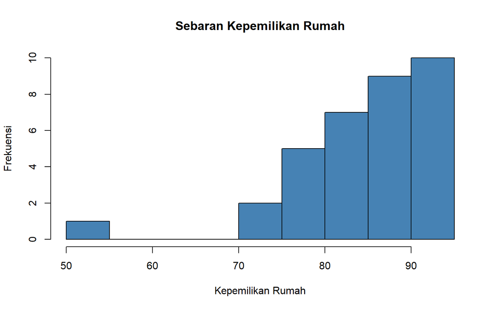

```r
hist(dt$Kepemilikan_Rumah,
     main = "Sebaran Kepemilikan Rumah",
     xlab = "Kepemilikan Rumah",
     ylab = "Frekuensi",
     col = "steelblue")
```

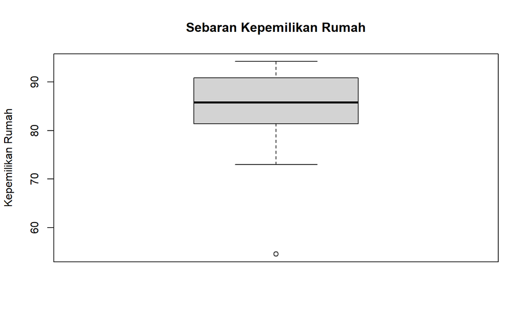

```r
boxplot(dt$Kepemilikan_Rumah,
        main = "Sebaran Kepemilikan Rumah",
        ylab = "Kepemilikan Rumah")
```

## Peubah Penjelas vs Peubah Respon

```r
# Ambil nama peubah penjelas secara dinamis
x_vars <- setdiff(names(dt), "Kepemilikan_Rumah")
```

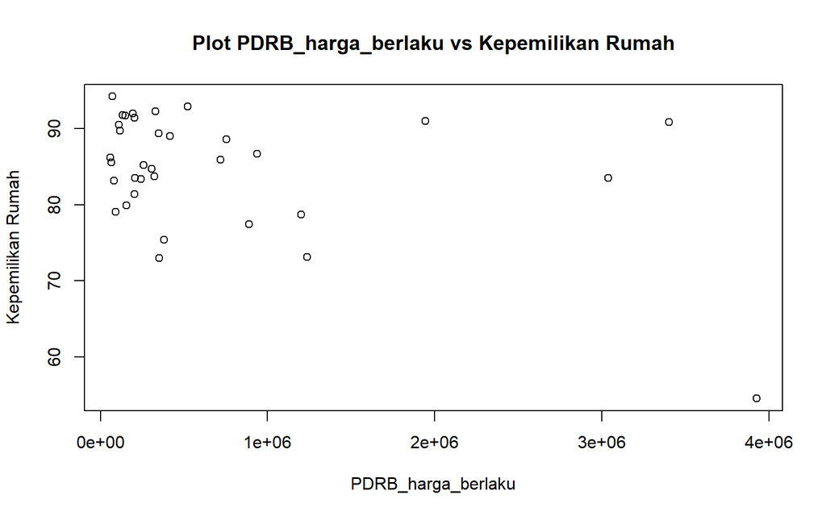

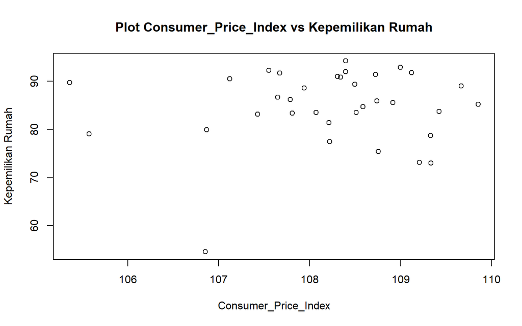

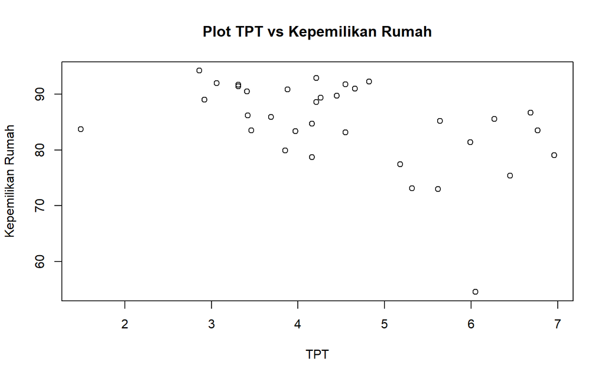

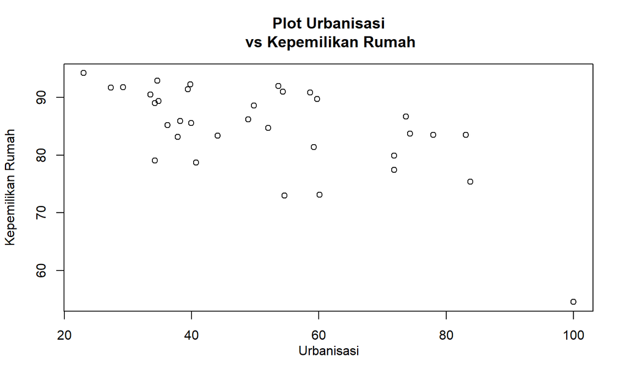

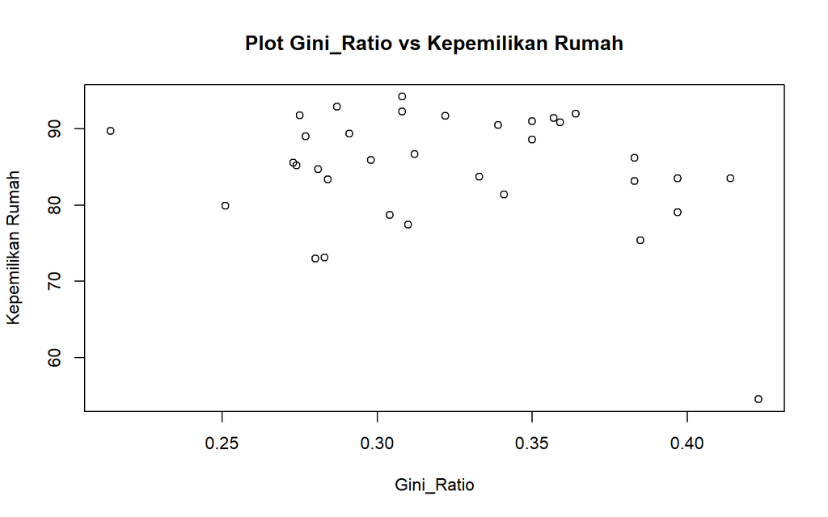

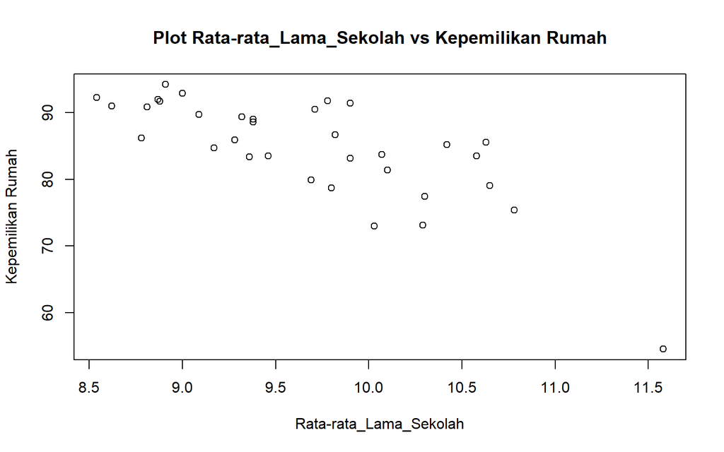

```r
for (xvar in x_vars) {
  plot(dt[[xvar]], dt$Kepemilikan_Rumah,
       xlab = xvar,
       ylab = "Kepemilikan Rumah",
       main = paste("Plot", xvar, "vs Kepemilikan Rumah"))
}
```

Hasil plot pencar antara masing-masing peubah penjelas terhadap Kepemilikan Rumah menunjukkan pola hubungan yang bervariasi. Beberapa peubah menunjukkan kecenderungan hubungan linear, sementara yang lain menunjukkan pola yang kurang linear atau terdapat amatan yang nilainya jauh dari amatan lainnya.

## Korelasi

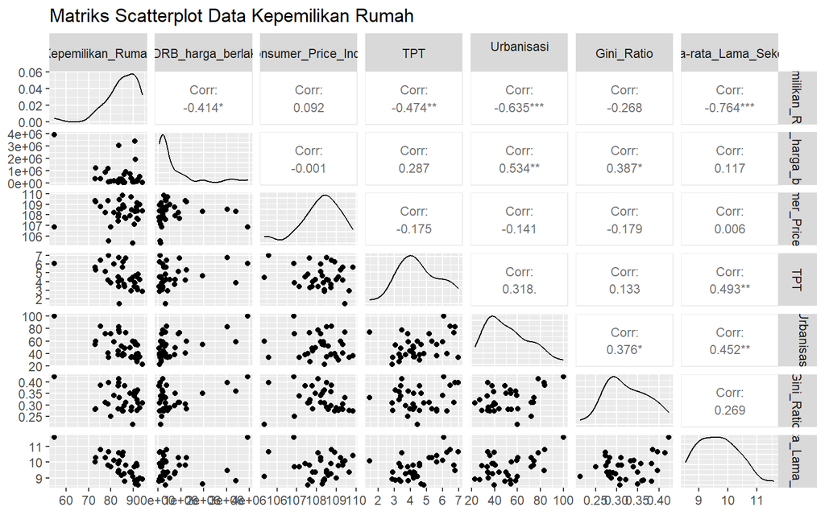

```r
ggpairs(dt,
        upper = list(continuous = wrap('cor', size = 3)),
        title = "Matriks Scatterplot Data Kepemilikan Rumah")
```

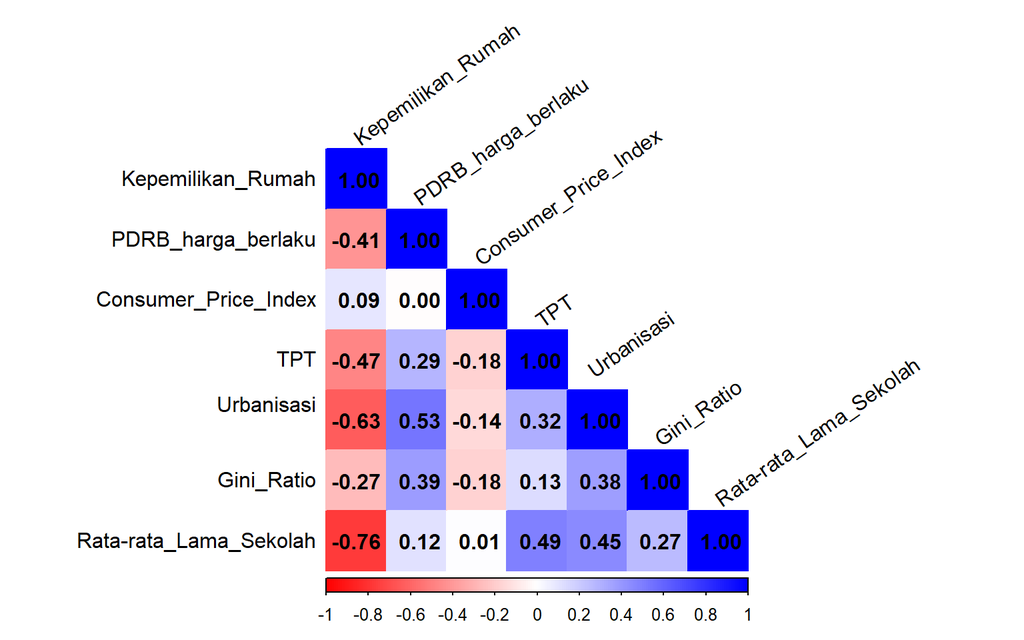

```r
cor_matrix <- cor(dt, use = "complete.obs")

corrplot(cor_matrix, method = "color", type = "lower",
         col = colorRampPalette(c("red", "white", "blue"))(200),
         addCoef.col = "black", tl.col = "black", tl.srt = 35)
```

Hasil matriks scatter plot dan korelasi menunjukkan hubungan antara peubah respon `Kepemilikan_Rumah` dan setiap peubah penjelas. Terdapat beberapa peubah yang memiliki korelasi cukup tinggi baik dengan peubah respon maupun dengan sesama peubah penjelas, sehingga mengindikasikan adanya potensi multikolinearitas yang perlu diperiksa lebih lanjut.

# Pemodelan

```r
model1 <- lm(formula = Kepemilikan_Rumah ~ ., data = dt)
summary(model1)
```

```
##
## Call:
## lm(formula = Kepemilikan_Rumah ~ ., data = dt)
##
## Residuals:
##     Min      1Q  Median      3Q     Max
## -9.4335 -2.4917 -0.1503  3.5144  6.2612
##
## Coefficients:
##                            Estimate Std. Error t value Pr(>|t|)
## (Intercept)               8.768e+01  8.779e+01   0.999   0.3268
## PDRB_harga_berlaku       -2.060e-06  1.056e-06  -1.951   0.0615 .
## Consumer_Price_Index      6.272e-01  8.109e-01   0.773   0.4460
## TPT                      -2.197e-02  7.406e-01  -0.030   0.9766
## `Urbanisasi\\r\\n`       -9.539e-02  5.647e-02  -1.689   0.1027
## Gini_Ratio                1.699e+01  1.798e+01   0.945   0.3530
## `Rata-rata_Lama_Sekolah` -7.228e+00  1.450e+00  -4.984 3.18e-05 ***
## ---
## Signif. codes:  0 '***' 0.001 '**' 0.01 '*' 0.05 '.' 0.1 ' ' 1
##
## Residual standard error: 4.484 on 27 degrees of freedom
## Multiple R-squared:  0.734,  Adjusted R-squared:  0.6749
## F-statistic: 12.42 on 6 and 27 DF,  p-value: 1.096e-06
```

Persamaan regresi berganda yang terbentuk dari seluruh peubah penjelas menunjukkan nilai koefisien untuk masing-masing peubah. Secara simultan, uji F menunjukkan minimal terdapat satu peubah penjelas yang berpengaruh signifikan terhadap Kepemilikan Rumah. Terdapat peubah yang mengalami perubahan tanda dugaan parameter dibandingkan arah korelasinya, yang mengindikasikan kemungkinan adanya permasalahan multikolinearitas dalam model. Selanjutnya diperlukan pemeriksaan multikolinearitas dilanjutkan dengan diagnosis sisaan.

# Pemeriksaan Multikolinearitas

## Perubahan Peubah

```r
# Buat model bertahap dengan penambahan peubah satu per satu
x_vars <- setdiff(names(dt), "Kepemilikan_Rumah")

mod1 <- lm(Kepemilikan_Rumah ~ ., dt[, c("Kepemilikan_Rumah", x_vars[1])])
mod2 <- lm(Kepemilikan_Rumah ~ ., dt[, c("Kepemilikan_Rumah", x_vars[1:2])])
mod3 <- lm(Kepemilikan_Rumah ~ ., dt[, c("Kepemilikan_Rumah", x_vars[1:3])])
mod4 <- lm(Kepemilikan_Rumah ~ ., dt[, c("Kepemilikan_Rumah", x_vars[1:4])])
mod5 <- lm(Kepemilikan_Rumah ~ ., dt)

stargazer(mod1, mod2, mod3, mod4, mod5,
          type = "text", single.row = TRUE)
```

```
##
## ====================================================================================================================================
##                                                                      Dependent variable:
##                          -----------------------------------------------------------------------------------------------------------
##                                                                       Kepemilikan_Rumah
##                                  (1)                  (2)                  (3)                   (4)                   (5)
## ------------------------------------------------------------------------------------------------------------------------------------
## PDRB_harga_berlaku       -0.00000** (0.00000) -0.00000** (0.00000) -0.00000* (0.00000)   -0.00000 (0.00000)    -0.00000* (0.00000)
## Consumer_Price_Index                             0.696 (1.243)        0.183 (1.179)        -0.259 (1.041)         0.627 (0.811)
## TPT                                                                  -2.309** (0.971)     -1.817** (0.864)        -0.022 (0.741)
## `Urbanisasirn`                                                                            -0.215*** (0.067)       -0.095 (0.056)
## Gini_Ratio                                                                                                       16.990 (17.977)
## `Rata-rata_Lama_Sekolah`                                                                                        -7.228*** (1.450)
## Constant                  86.993*** (1.535)     11.728 (134.560)     77.005 (128.433)     132.344 (113.727)      87.675 (87.791)
## ------------------------------------------------------------------------------------------------------------------------------------
## Observations                      34                   34                   34                   34                     34
## R2                              0.171                0.179                0.309                 0.489                 0.734
## Adjusted R2                     0.145                0.126                0.240                 0.418                 0.675
## Residual Std. Error        7.271 (df = 32)      7.351 (df = 31)      6.854 (df = 30)       5.998 (df = 29)       4.484 (df = 27)
## F Statistic              6.601** (df = 1; 32) 3.386** (df = 2; 31) 4.482** (df = 3; 30) 6.932*** (df = 4; 29) 12.417*** (df = 6; 27)
## ====================================================================================================================================
## Note:                                                                                                    *p<0.1; **p<0.05; ***p<0.01
```

## Perubahan Banyak Data

```r
mod5_1 <- lm(Kepemilikan_Rumah ~ ., dt[1:round(nrow(dt)*0.7), ])
stargazer(summary(mod5)$coefficients, summary(mod5_1)$coefficients,
          type = "text",
          font.size = "small")
```

```
##
## ================================================================
##                          Estimate Std. Error t value Pr(> | t| )
## ----------------------------------------------------------------
## (Intercept)               87.675    87.791    0.999     0.327
## PDRB_harga_berlaku       -0.00000  0.00000   -1.951     0.062
## Consumer_Price_Index      0.627     0.811     0.773     0.446
## TPT                       -0.022    0.741    -0.030     0.977
## `Urbanisasirn`            -0.095    0.056    -1.689     0.103
## Gini_Ratio                16.990    17.977    0.945     0.353
## `Rata-rata_Lama_Sekolah`  -7.228    1.450    -4.984    0.00003
## ----------------------------------------------------------------
##
## ================================================================
##                          Estimate Std. Error t value Pr(> | t| )
## ----------------------------------------------------------------
## (Intercept)              157.862   103.587    1.524     0.146
## PDRB_harga_berlaku       -0.00000  0.00000   -2.517     0.022
## Consumer_Price_Index      0.055     0.992     0.056     0.956
## TPT                       0.047     0.857     0.055     0.957
## `Urbanisasirn`            -0.046    0.076    -0.612     0.548
## Gini_Ratio                43.221    23.716    1.822     0.086
## `Rata-rata_Lama_Sekolah`  -9.226    1.685    -5.476    0.00004
## ----------------------------------------------------------------
```

## Akar Ciri

```r
x_mat <- dt[, x_vars]
r <- cor(x_mat)
(ev <- eigen(r)$values)
```

```
## [1] 2.3979462 1.0528908 1.0218952 0.7199625 0.5459354 0.2613699
```

```r
# Simultan
if ((max(ev) / min(ev)) <= 100) {
  cat("Tidak ada multikolinearitas\n")
} else if ((max(ev) / min(ev)) > 100 & (max(ev) / min(ev)) <= 1000) {
  cat("Ada multikolinearitas yang lemah\n")
} else {
  cat("Ada multikolinearitas yang kuat\n")
}
```

```
## Tidak ada multikolinearitas
```

```r
# Parsial
if (all((max(ev) / ev) <= 1000)) {
  cat("Tidak ada multikolinearitas\n")
} else {
  cat("Ada multikolinearitas pada peubah penjelas ke:", which((max(ev) / ev) > 1000), "\n")
}
```

```
## Tidak ada multikolinearitas
```

## Nilai VIF

```r
vif(model1)
```

```
##       PDRB_harga_berlaku     Consumer_Price_Index                      TPT
##                 1.730764                 1.143036                 1.531969
##       `Urbanisasi\\r\\n`               Gini_Ratio `Rata-rata_Lama_Sekolah`
##                 1.869204                 1.345154                 1.771912
```

# Pemodelan Penyisihan Peubah

```r
# Identifikasi peubah dengan VIF tertinggi untuk disisihkan
vif_values <- vif(model1)
cat("Nilai VIF masing-masing peubah:\n")
```

```
## Nilai VIF masing-masing peubah:
```

```r
print(vif_values)
```

```
##       PDRB_harga_berlaku     Consumer_Price_Index                      TPT
##                 1.730764                 1.143036                 1.531969
##       `Urbanisasi\\r\\n`               Gini_Ratio `Rata-rata_Lama_Sekolah`
##                 1.869204                 1.345154                 1.771912
```

```r
# Peubah dengan VIF tertinggi
peubah_vif_tinggi <- names(which.max(vif_values))
cat("\nPeubah dengan VIF tertinggi yang disisihkan:", peubah_vif_tinggi, "\n")
```

```
##
## Peubah dengan VIF tertinggi yang disisihkan: `Urbanisasi\r\n`
```

```r
# Peubah penjelas yang dipertahankan
x_vars_red <- setdiff(x_vars, peubah_vif_tinggi)
cat("Peubah penjelas yang dipertahankan:", paste(x_vars_red, collapse = ", "), "\n")
```

```
## Peubah penjelas yang dipertahankan: PDRB_harga_berlaku, Consumer_Price_Index, TPT, Urbanisasi
## , Gini_Ratio, Rata-rata_Lama_Sekolah
```

```r
names(dt) <- names(dt) |>
  trimws() |>
  gsub("[\r\n]", "", x = _) |>
  make.names()
names(dt) <- trimws(gsub("[\r\n]", "", names(dt)))
x_vars <- setdiff(names(dt), "Kepemilikan_Rumah")

vif_values <- vif(model1)
peubah_vif_tinggi <- names(which.max(vif_values))
x_vars_red <- setdiff(x_vars, peubah_vif_tinggi)

formula_red <- reformulate(
  x_vars_red,
  response = "Kepemilikan_Rumah"
)

model2 <- lm(formula_red, data = dt)
summary(model2)
```

```
##
## Call:
## lm(formula = formula_red, data = dt)
##
## Residuals:
##     Min      1Q  Median      3Q     Max
## -9.4335 -2.4917 -0.1503  3.5144  6.2612
##
## Coefficients:
##                          Estimate Std. Error t value Pr(>|t|)
## (Intercept)             8.768e+01  8.779e+01   0.999   0.3268
## PDRB_harga_berlaku     -2.060e-06  1.056e-06  -1.951   0.0615 .
## Consumer_Price_Index    6.272e-01  8.109e-01   0.773   0.4460
## TPT                    -2.197e-02  7.406e-01  -0.030   0.9766
## Urbanisasi             -9.539e-02  5.647e-02  -1.689   0.1027
## Gini_Ratio              1.699e+01  1.798e+01   0.945   0.3530
## Rata.rata_Lama_Sekolah -7.228e+00  1.450e+00  -4.984 3.18e-05 ***
## ---
## Signif. codes:  0 '***' 0.001 '**' 0.01 '*' 0.05 '.' 0.1 ' ' 1
##
## Residual standard error: 4.484 on 27 degrees of freedom
## Multiple R-squared:  0.734,  Adjusted R-squared:  0.6749
## F-statistic: 12.42 on 6 and 27 DF,  p-value: 1.096e-06
```

```r
formula_red <- as.formula(paste("Kepemilikan_Rumah ~", paste(x_vars_red, collapse = " + ")))
model2 <- lm(formula_red, data = dt)
summary(model2)
```

```
##
## Call:
## lm(formula = formula_red, data = dt)
##
## Residuals:
##     Min      1Q  Median      3Q     Max
## -9.4335 -2.4917 -0.1503  3.5144  6.2612
##
## Coefficients:
##                          Estimate Std. Error t value Pr(>|t|)
## (Intercept)             8.768e+01  8.779e+01   0.999   0.3268
## PDRB_harga_berlaku     -2.060e-06  1.056e-06  -1.951   0.0615 .
## Consumer_Price_Index    6.272e-01  8.109e-01   0.773   0.4460
## TPT                    -2.197e-02  7.406e-01  -0.030   0.9766
## Urbanisasi             -9.539e-02  5.647e-02  -1.689   0.1027
## Gini_Ratio              1.699e+01  1.798e+01   0.945   0.3530
## Rata.rata_Lama_Sekolah -7.228e+00  1.450e+00  -4.984 3.18e-05 ***
## ---
## Signif. codes:  0 '***' 0.001 '**' 0.01 '*' 0.05 '.' 0.1 ' ' 1
##
## Residual standard error: 4.484 on 27 degrees of freedom
## Multiple R-squared:  0.734,  Adjusted R-squared:  0.6749
## F-statistic: 12.42 on 6 and 27 DF,  p-value: 1.096e-06
```

## Nilai VIF

```r
vif(model2)
```

```
##     PDRB_harga_berlaku   Consumer_Price_Index                    TPT
##               1.730764               1.143036               1.531969
##             Urbanisasi             Gini_Ratio Rata.rata_Lama_Sekolah
##               1.869204               1.345154               1.771912
```

# Pengujian Asumsi

## Eksplorasi Grafik

### Plot Sisaan vs Y duga

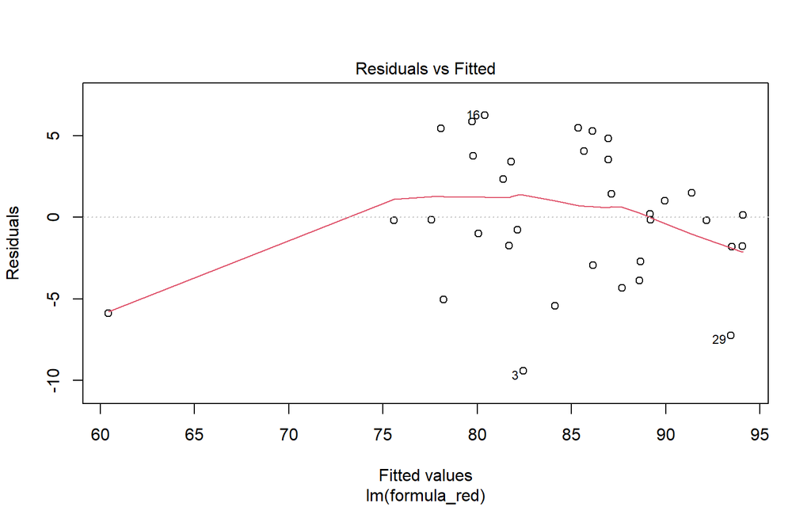

```r
plot(model2, 1)
```

Hasil plot sisaan terhadap nilai dugaan memberikan informasi mengenai pemenuhan asumsi nilai harapan sisaan sama dengan nol dan kehomogenan ragam sisaan. Apabila tebaran sisaan tidak memperlihatkan pola tertentu dan tersebar merata di sekitar nol, maka kedua asumsi tersebut terpenuhi. Sebaliknya, apabila terdapat pola seperti corong atau kecenderungan naik/turun, maka terdapat indikasi pelanggaran asumsi.

### Plot Sisaan vs Urutan

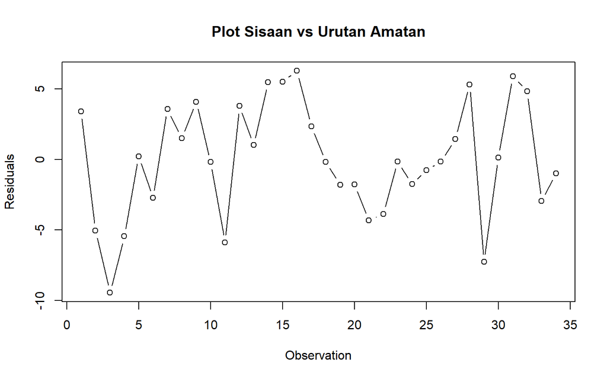

```r
plot(x = 1:dim(dt)[1],
     y = model2$residuals,
     type = 'b',
     ylab = "Residuals",
     xlab = "Observation",
     main = "Plot Sisaan vs Urutan Amatan")
```

Tebaran sisaan terhadap urutan amatan digunakan untuk mengevaluasi asumsi kebebasan sisaan. Apabila tidak terdapat pola yang berulang atau kecenderungan tertentu, maka sisaan dapat dinyatakan saling bebas. Namun apabila terdapat pola yang menyerupai gelombang atau kecenderungan yang konsisten, maka ada indikasi autokorelasi.

### QQ plot

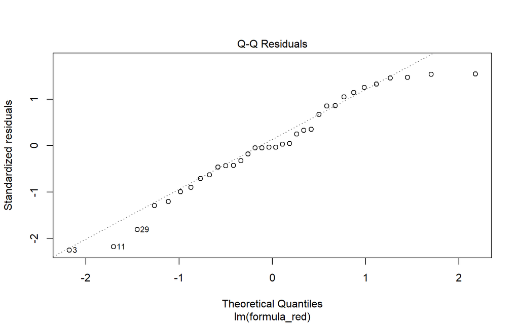

```r
plot(model2, 2)
```

QQ plot digunakan untuk memeriksa asumsi kenormalan sisaan. Apabila titik-titik amatan cenderung mengikuti garis diagonal, maka asumsi normalitas sisaan terpenuhi. Penyimpangan yang signifikan dari garis diagonal mengindikasikan pelanggaran asumsi normalitas.

## Uji Formal

### Nilai harapan sisaan sama dengan nol

```r
t.test(model2$residuals, mu = 0, conf.level = 0.95)
```

```
##
##  One Sample t-test
##
## data:  model2$residuals
## t = -3.4034e-16, df = 33, p-value = 1
## alternative hypothesis: true mean is not equal to 0
## 95 percent confidence interval:
##  -1.415228  1.415228
## sample estimates:
##     mean of x
## -2.367403e-16
```

Uji t digunakan untuk menguji apakah nilai harapan sisaan sama dengan nol. Apabila nilai p lebih besar dari taraf nyata 5%, maka asumsi nilai harapan sisaan sama dengan nol dinyatakan terpenuhi.

### Ragam sisaan homogen

```r
bptest(model2)
```

```
##
##  studentized Breusch-Pagan test
##
## data:  model2
## BP = 3.2342, df = 6, p-value = 0.7789
```

Uji Breusch-Pagan digunakan untuk menguji kehomogenan ragam sisaan (homoskedastisitas). Apabila nilai p lebih besar dari taraf nyata 5%, maka asumsi ragam sisaan homogen dinyatakan terpenuhi.

### Sisaan saling bebas

```r
dwtest(model2)
```

```
##
##  Durbin-Watson test
##
## data:  model2
## DW = 1.372, p-value = 0.01756
## alternative hypothesis: true autocorrelation is greater than 0
```

Uji Durbin-Watson digunakan untuk menguji apakah sisaan saling bebas (tidak terjadi autokorelasi). Apabila nilai p lebih besar dari taraf nyata 5%, maka asumsi sisaan saling bebas dinyatakan terpenuhi.

### Normalitas Sisaan

```r
shapiro.test(model2$residuals)
```

```
##
##  Shapiro-Wilk normality test
##
## data:  model2$residuals
## W = 0.96836, p-value = 0.4177
```

Uji Shapiro-Wilk digunakan untuk menguji kenormalan sisaan. Apabila nilai p lebih besar dari taraf nyata 5%, maka asumsi normalitas sisaan dinyatakan terpenuhi. Jika seluruh asumsi terpenuhi namun model masih kurang baik, kemungkinan disebabkan oleh keberadaan amatan tidak biasa seperti pencilan, titik leverage, atau amatan berpengaruh yang perlu diperiksa lebih lanjut.

# Pemeriksaan Amatan Tidak Biasa

```r
# fungsi
ri_stud <- rstudent(model2)
ri_stan <- rstandard(model2)
hii_fungsi <- hatvalues(model2)

# gunakan nilai fungsi langsung (tanpa perhitungan manual)
nilai <- data.frame(
  ri_stud = ri_stud,
  ri_stan = ri_stan,
  hii_fungsi = hii_fungsi
)

nilai
```

```
##        ri_stud     ri_stan hii_fungsi
## 1   0.85433298  0.85863880 0.21880539
## 2  -1.21678953 -1.20610307 0.12936967
## 3  -2.45953518 -2.25748855 0.13157725
## 4  -1.30836674 -1.29145366 0.11760593
## 5   0.04700427  0.04789764 0.05909169
## 6  -0.62193963 -0.62912462 0.06644403
## 7   0.86039877  0.86456697 0.16078502
## 8   0.34418535  0.34994553 0.08823976
## 9   1.35221090  1.33193066 0.53548325
## 10 -0.04987236 -0.05081996 0.31301430
## 11 -2.36303514 -2.18483650 0.63947611
## 12  1.05700002  1.05471243 0.36361797
## 13  0.24456851  0.24894119 0.18346855
## 14  1.49198606  1.45922348 0.30260172
```

[output cut: 20 more lines]

## Pencilan

```r
for (i in 1:dim(nilai)[1]) {
  absri <- abs(nilai[, 2])
  pencilan <- which(absri > 2)
}
pencilan
```

```
## [1]  3 11
```

Amatan yang terdeteksi sebagai pencilan adalah amatan-amatan dengan nilai sisaan terstandarisasi (|r_i| > 2) yang perlu mendapat perhatian lebih lanjut dalam analisis.

## Leverage

```r
n <- dim(dt)[1]
p <- length(model2$coefficients)

for (i in 1:dim(nilai)[1]) {
  cutoff <- 2 * p / n
  titik_leverage <- which(hii_fungsi > cutoff)
}
titik_leverage
```

```
##  9 11 34
##  9 11 34
```

Amatan yang terdeteksi sebagai titik leverage adalah amatan-amatan dengan nilai leverage (h_ii) yang melebihi ambang batas 2p/n. Titik leverage merupakan amatan dengan nilai peubah penjelas yang jauh dari rata-rata dan berpotensi memengaruhi kecocokan model.

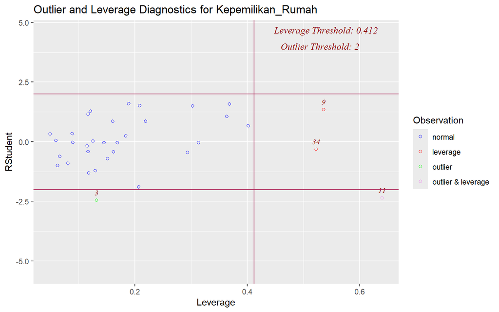

```r
ols_plot_resid_lev(model2)
```

Plot yang terbentuk dari fungsi `ols_plot_resid_lev()` menyajikan gambaran visual mengenai keberadaan pencilan dan titik leverage secara bersamaan. Amatan yang teridentifikasi pada plot ini perlu diperiksa lebih lanjut untuk memastikan pengaruhnya terhadap model.

## Amatan Berpengaruh

### Jarak Cook

```r
di <- cooks.distance(model2)
f  <- qf(0.05, p, n - p, lower.tail = FALSE)
data.frame(di, di > f)
```

```
##              di di...f
## 1  2.949998e-02  FALSE
## 2  3.087945e-02  FALSE
## 3  1.103069e-01  FALSE
## 4  3.175603e-02  FALSE
## 5  2.058303e-05  FALSE
## 6  4.024305e-03  FALSE
## 7  2.045840e-02  FALSE
## 8  1.693115e-03  FALSE
## 9  2.921526e-01  FALSE
## 10 1.681075e-04  FALSE
## 11 1.209568e+00  FALSE
## 12 9.080244e-02  FALSE
## 13 1.989226e-03  FALSE
## 14 1.319885e-01  FALSE
```

[output cut: 20 more lines]

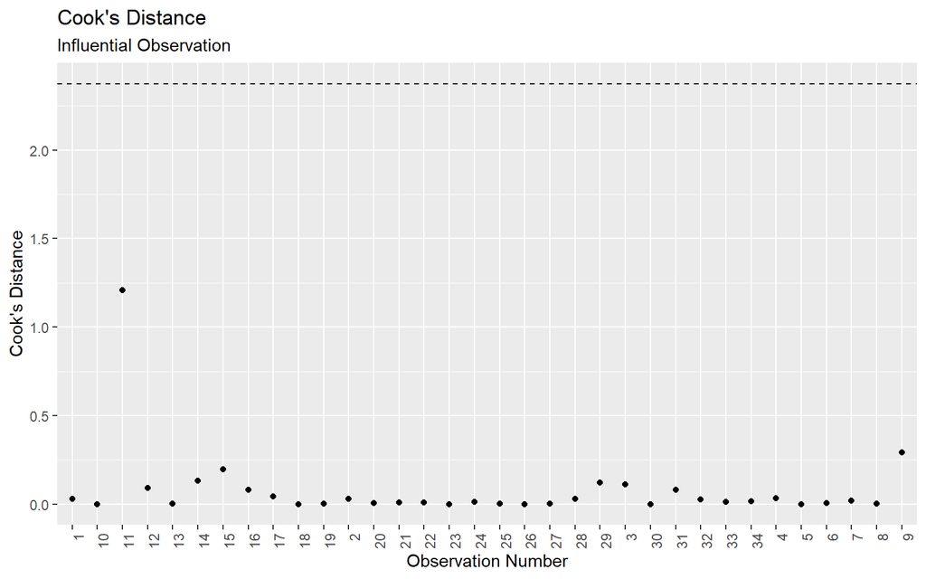

```r
cooks_crit   <- f
model_cooks  <- cooks.distance(model2)
df_cooks     <- data.frame(obs   = names(model_cooks),
                            cooks = model_cooks)

ggplot(df_cooks, aes(y = cooks, x = obs)) +
  geom_point() +
  geom_hline(yintercept = cooks_crit, linetype = "dashed") +
  labs(title    = "Cook's Distance",
       subtitle = "Influential Observation",
       x        = "Observation Number",
       y        = "Cook's Distance") +
  theme(axis.text.x = element_text(angle = 90, hjust = 1))
```

Pemeriksaan amatan berpengaruh menggunakan jarak Cook dilakukan dengan membandingkan nilai jarak Cook setiap amatan terhadap ambang batas F(0.05; p; n-p). Amatan yang melampaui ambang batas dinyatakan sebagai amatan berpengaruh yang dapat memengaruhi estimasi parameter secara keseluruhan.

### DFBETAS

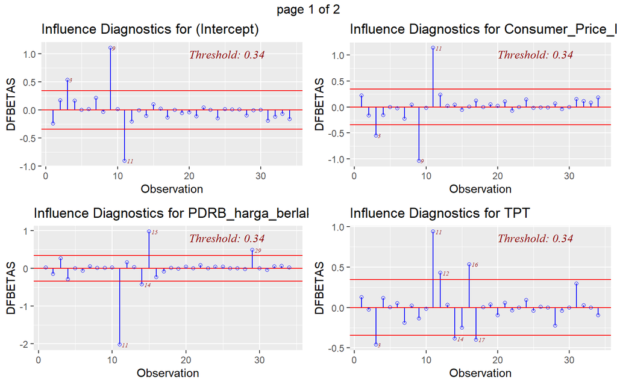

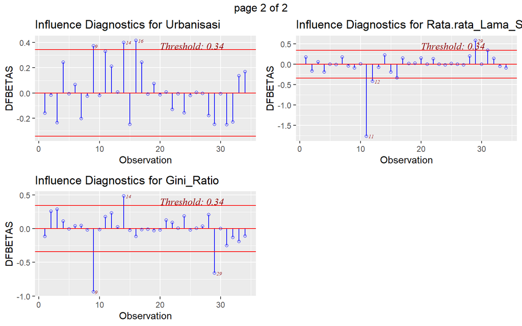

```r
ols_plot_dfbetas(model2)
```

Hasil DFBETAS menunjukkan pengaruh setiap observasi terhadap masing-masing koefisien regresi sehingga terdapat output untuk setiap parameter. DFBETAS mengukur seberapa besar koefisien regresi berubah apabila suatu observasi dihapus dari model.

### DFFITS

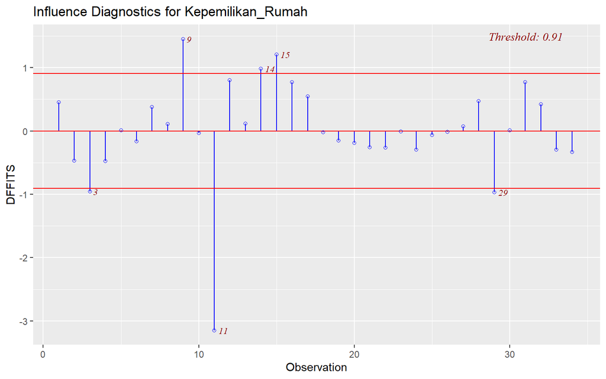

```r
ols_plot_dffits(model2)
```

Hasil DFFITS menunjukkan pengaruh observasi terhadap nilai prediksi Y sehingga hanya menghasilkan satu output. DFFITS mengukur seberapa besar nilai prediksi $\hat{Y}_i$ berubah apabila suatu observasi dihapus dari model, sehingga lebih tepat digunakan untuk melihat pengaruh observasi terhadap hasil model secara keseluruhan.

```r
DFFITSi <- dffits(model2)

amatan_berpengaruh <- vector("list", dim(nilai)[1])
for (i in 1:dim(nilai)[1]) {
  cutoff <- 2 * sqrt(p / n)
  amatan_berpengaruh[[i]] <- which(abs(DFFITSi) > cutoff)
}
berpengaruh        <- unlist(amatan_berpengaruh)
amatan_berpengaruh <- sort(unique(berpengaruh))
amatan_berpengaruh
```

```
## [1]  3  9 11 14 15 29
```

Amatan yang teridentifikasi memiliki nilai DFFITS melebihi ambang batas dinyatakan sebagai amatan berpengaruh yang memengaruhi nilai prediksi model secara signifikan. Amatan tersebut sangat riskan apabila disisihkan dan perlu ditelusuri lebih lanjut.

# Pemodelan Penyisihan Amatan

```r
# Gunakan peubah penjelas yang sudah diseleksi (formula_red dari pemodelan sebelumnya)

# Identifikasi amatan tidak biasa: pencilan, leverage, dan amatan berpengaruh
amatan_12 <- pencilan[1]      # amatan pertama yang terdeteksi sebagai pencilan
amatan_21 <- amatan_berpengaruh[1]  # amatan pertama yang terdeteksi berpengaruh
amatan_22 <- titik_leverage[1]     # amatan pertama yang terdeteksi sebagai leverage

dt1 <- dt %>% slice(-amatan_12)
model3 <- lm(formula_red, dt1)

dt2 <- dt %>% slice(-amatan_21)
model4 <- lm(formula_red, dt2)

dt3 <- dt %>% slice(-amatan_22)
model5 <- lm(formula_red, dt3)

dt4 <- dt %>% slice(-c(amatan_12, amatan_21))
model6 <- lm(formula_red, dt4)

dt5 <- dt %>% slice(-c(amatan_12, amatan_22))
model7 <- lm(formula_red, dt5)

dt6 <- dt %>% slice(-c(amatan_21, amatan_22))
model8 <- lm(formula_red, dt6)

dt7 <- dt %>% slice(-c(amatan_12, amatan_21, amatan_22))
model9 <- lm(formula_red, dt7)
```

```r
get_metrics <- function(model) {
  adj_r2 <- summary(model)$adj.r.squared
  sse    <- sum(model$residuals^2)
  return(c(adj_r2, sse))
}

model_metrics <- data.frame(
  Model        = c("Model 2", "Model 3", "Model 4", "Model 5",
                   "Model 6", "Model 7", "Model 8", "Model 9"),
  Adjusted_R2  = sapply(list(model2, model3, model4, model5,
                             model6, model7, model8, model9),
                        function(m) get_metrics(m)[1]),
  SSE          = sapply(list(model2, model3, model4, model5,
                             model6, model7, model8, model9),
                        function(m) get_metrics(m)[2])
)

print(model_metrics)
```

```
##     Model Adjusted_R2      SSE
## 1 Model 2   0.6748876 542.9048
## 2 Model 3   0.7147863 440.4315
## 3 Model 4   0.7147863 440.4315
## 4 Model 5   0.6901585 507.2332
## 5 Model 6   0.7147863 440.4315
## 6 Model 7   0.7333704 403.8075
## 7 Model 8   0.7333704 403.8075
## 8 Model 9   0.7333704 403.8075
```

Berdasarkan hasil perbandingan model, model terbaik dipilih berdasarkan nilai adjusted R-squared tertinggi dan SSE terkecil. Model dengan penyisihan amatan yang tepat diharapkan menghasilkan estimasi parameter yang lebih stabil dan akurat dibandingkan model yang menggunakan seluruh amatan.

```r
stargazer(model2, model4, model9, type = "text", font.size = "small",
          report = "vc*p")
```

```
##
## ===========================================================================================
##                                                Dependent variable:
##                        --------------------------------------------------------------------
##                                                 Kepemilikan_Rumah
##                                 (1)                    (2)                    (3)
## -------------------------------------------------------------------------------------------
## PDRB_harga_berlaku           -0.00000*              -0.00000**             -0.00000**
##                              p = 0.062              p = 0.025              p = 0.022
##
## Consumer_Price_Index           0.627                  1.035                  1.876*
##                              p = 0.446              p = 0.187              p = 0.055
##
## TPT                            -0.022                 0.291                  0.393
##                              p = 0.977              p = 0.678              p = 0.569
##
## Urbanisasi                     -0.095                 -0.083                -0.104*
##                              p = 0.103              p = 0.123              p = 0.060
##
## Gini_Ratio                     16.990                 12.229                 29.048
##                              p = 0.353              p = 0.469              p = 0.153
##
## Rata.rata_Lama_Sekolah       -7.228***              -7.297***              -7.156***
##                             p = 0.00004            p = 0.00001            p = 0.00002
##
## Constant                       87.675                 44.204                -53.230
##                              p = 0.327              p = 0.597              p = 0.611
##
## -------------------------------------------------------------------------------------------
## Observations                     34                     33                     32
## R2                             0.734                  0.768                  0.785
## Adjusted R2                    0.675                  0.715                  0.733
## Residual Std. Error       4.484 (df = 27)        4.116 (df = 26)        4.019 (df = 25)
## F Statistic            12.417*** (df = 6; 27) 14.366*** (df = 6; 26) 15.211*** (df = 6; 25)
## ===========================================================================================
## Note:                                                           *p<0.1; **p<0.05; ***p<0.01
```

Perbandingan antara model tanpa penyisihan amatan (model2), model dengan penyisihan amatan berpengaruh tunggal (model4), dan model dengan penyisihan beberapa amatan sekaligus (model9) menunjukkan perbedaan nilai dugaan parameter, tingkat signifikansi, serta kualitas kecocokan model. Model yang menghasilkan koefisien dengan tanda yang sesuai dengan arah korelasi dan nilai adjusted R-squared yang lebih tinggi dapat dijadikan pertimbangan sebagai model terbaik.